# Montserrat Forest Bird Monitoring - Annual Summary 2023

Department of Environment / RSPB

The forests on Montserrat are home for two globally threatened forest bird species, the endemic Montserrat Oriole and the Forest Thrush. Since 1999 the Department of Environment and the RSPB have counted the forest birds in the Center Hills along 11 survey routes at least once per year at the beginning of the birds’ breeding season in April.

### Summary of raw observations in April and May 2023

Observed number of forest birds in the Centre Hills of Montserrat in April and May 2023 during three independent survey rounds.

| Species | Total N in round 1 | Total N in round 2 | Total N in round 3 |
| --- | --- | --- | --- |
| PEARLY-EYED THRASHER | 488 | 454 | 458 |
| SCALY-NAPED PIGEON | 292 | 326 | 369 |
| SCALY-BREASTED THRASHER | 249 | 201 | 203 |
| BANANAQUIT | 245 | 248 | 214 |
| FOREST THRUSH | 230 | 219 | 238 |
| ANTILLEAN CRESTED HUMMINGBIRD | 107 | 80 | 76 |
| BRIDLED QUAIL-DOVE | 106 | 82 | 85 |
| MONTSERRAT ORIOLE | 105 | 77 | 76 |
| BROWN TREMBLER | 99 | 95 | 100 |
| PURPLE-THROATED CARIB | 77 | 62 | 57 |
| ZENAIDA DOVE | 49 | 72 | 69 |
| MANGROVE CUCKOO | 46 | 57 | 75 |
| LESSER ANTILLEAN BULLFINCH | 38 | 22 | 11 |
| AMERICAN KESTREL | 9 | 3 | 3 |
| COMMON GROUND-DOVE | 7 | 1 | 4 |
| BLACK-WHISKERED VIREO | 6 | 5 | 3 |
| CARIBBEAN MARTIN | 4 | 0 | 0 |
| SMOOTH-BILLED ANI | 4 | 0 | 1 |
| BLACK-FACED GRASSQUIT | 3 | 1 | 1 |
| Common Gallinule | 1 | 0 | 0 |
| GREEN-THROATED CARIB | 1 | 3 | 1 |
| HOODED WARBLER | 1 | 0 | 0 |
| YELLOW WARBLER | 1 | 0 | 0 |
| GREEN-BACK HERON | 0 | 0 | 1 |
| LOUISIANA WATERTHRUSH | 0 | 1 | 0 |

### Estimate of forest bird trends on Montserrat since 2011

Since the survey design with three repeated counts at each point was introduced in 2011, we use binomial mixture models to estimate the abundance of birds around all survey points, and the long term trend across years. The three repeated visits allow us to estimate what proportion of birds were not seen during the surveys, so that the estimated number is less affected by temporal changes in weather or bird calling activity, and the estimated trend should not be affected by differences between observation conditions in different years.

There is no indication that the two globally threatened species (Montserrat Oriole and Forest Thrush) have decreased since 2011, in fact, the Montserrat Oriole appears to have slightly increased. However, Green-throated Caribs appear to have been affected by the hurricanes in 2017, and both Green-throated Caribs and Caribbean Elaenia have a long-term negative trend (Fig. 1, Table 2).

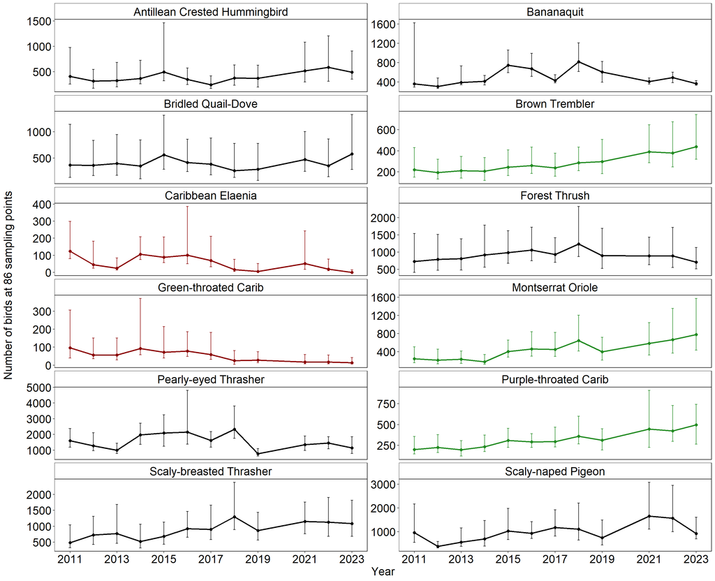

*Figure 1: Estimated abundance of 12 forest bird species around 86 point count locations in the Center Hills of Montserrat since 2011. Species shown with green lines are increasing, species with red lines are decreasing, and species with black lines are stable (or have no discernible trend direction).*

Estimated trend of 12 forest bird species surveyed between 2011 and 2023 in the Centre Hills of Montserrat. Note that ‘model fit’ is assessed via a Bayesian p-value, which indicates poor model fit at values close to 0 and close to 1.

| Species | Direction | Trend estimate | Model fit |
| --- | --- | --- | --- |
| Montserrat Oriole | increase | 0.108 (0.02 - 0.196) | 0.2090333 |
| Forest Thrush | stable | 0.004 (-0.069 - 0.08) | 0.2828000 |
| Bridled Quail-Dove | stable | 0.033 (-0.095 - 0.339) | 0.2894000 |
| Brown Trembler | increase | 0.066 (0.01 - 0.123) | 0.3877000 |
| Antillean Crested Hummingbird | stable | 0.031 (-0.048 - 0.117) | 0.9935000 |
| Purple-throated Carib | increase | 0.075 (0.003 - 0.139) | 0.9957000 |
| Pearly-eyed Thrasher | stable | -0.017 (-0.094 - 0.058) | 0.9931000 |
| Green-throated Carib | decrease | -0.157 (-0.308 - -0.031) | 0.4155000 |
| Scaly-breasted Thrasher | stable | 0.062 (-0.018 - 0.139) | 0.8188667 |
| Scaly-naped Pigeon | stable | 0.066 (-0.025 - 0.149) | 0.1986000 |
| Caribbean Elaenia | (decrease) | -0.227 (-0.525 - 0.022) | 0.4992000 |
| Bananaquit | stable | 0.006 (-0.085 - 0.071) | 1.0000000 |